# Assignment5

Neelima Cherukuri

2022-06-07

```r
library(XML)
library(xml2)
library(RCurl)
library(dplyr)
library(stringr)
library(tidyverse)
```

```r
library(ggplot2)
library(tidyr)
library(lubridate)
library(scales)
library(readr)
```

Question 1 : Load the XML data directly from the URL below into a data frame (or tibble) and display the dimensions of the data. URL: https://www.senate.gov/general/contact_information/senators_cfm.xml. If you get errors while loading the XML file, ensure that you use the RCurl package. Refer to this post for details.

```r
fileurl <- "https://www.senate.gov/general/contact_information/senators_cfm.xml"
download.file(fileurl, destfile = "senators_cfm.xml")
Senators <- xmlToDataFrame("senators_cfm.xml")
dim(Senators)
```

```
## [1] 101  13
```

```r
str(Senators)
```

```
## 'data.frame':    101 obs. of  13 variables:
##  $ member_full        : chr  "Baldwin (D-WI)" "Barrasso (R-WY)" "Bennet (D-CO)" "Blackburn (R-TN)" ...
##  $ last_name          : chr  "Baldwin" "Barrasso" "Bennet" "Blackburn" ...
##  $ first_name         : chr  "Tammy" "John" "Michael F." "Marsha" ...
##  $ party              : chr  "D" "R" "D" "R" ...
##  $ state              : chr  "WI" "WY" "CO" "TN" ...
##  $ address            : chr  "709 Hart Senate Office Building Washington DC 20510" "307 Dirksen Senate Office Building Washington DC 20510" "261 Russell Senate Office Building Washington DC 20510" "357 Dirksen Senate Office Building Washington DC 20510" ...
##  $ phone              : chr  "(202) 224-5653" "(202) 224-6441" "(202) 224-5852" "(202) 224-3344" ...
##  $ email              : chr  "https://www.baldwin.senate.gov/feedback" "https://www.barrasso.senate.gov/public/index.cfm/contact-form" "https://www.bennet.senate.gov/public/index.cfm/contact" "https://www.blackburn.senate.gov/email-me" ...
##  $ website            : chr  "https://www.baldwin.senate.gov/" "https://www.barrasso.senate.gov" "https://www.bennet.senate.gov" "https://www.blackburn.senate.gov" ...
##  $ class              : chr  "Class I" "Class I" "Class III" "Class I" ...
##  $ bioguide_id        : chr  "B001230" "B001261" "B001267" "B001243" ...
##  $ leadership_position: chr  NA NA NA NA ...
##  $ text               : chr  NA NA NA NA ...
```

#Explanation: This dataframe has 101 rows and 13 columns

Question 2: Construct a regular expression (regex) to extract only the first, last names, and party (D,R,I) of each senator; the regex should remove their middle initial and/or suffix e.g. remove Jr. III, etc. Ensure that the updated names are reflected in the dataframe.

```r
#Extracting names and removing middle name and initials

new_first_name <- gsub('([A-z]+).*', '\\1', Senators$first_name)
new_first_name
```

```
##   [1] "Tammy"       "John"        "Michael"     "Marsha"      "Richard"
##   [6] "Roy"         "Cory"        "John"        "Mike"        "Sherrod"
##  [11] "Richard"     "Maria"       "Shelley"     "Benjamin"    "Thomas"
##  [16] "Robert"      "Bill"        "Susan"       "Christopher" "John"
##  [21] "Catherine"   "Tom"         "Kevin"       "Mike"        "Ted"
##  [26] "Steve"       "Tammy"       "Richard"     "Joni"        "Dianne"
##  [31] "Deb"         "Kirsten"     "Lindsey"     "Chuck"       "Bill"
##  [36] "Margaret"    "Josh"        "Martin"      "John"        "Mazie"
##  [41] "John"        "Cindy"       "James"       "Ron"         "Tim"
##  [46] "Mark"        "John"        "Angus"       "Amy"         "James"
##  [51] "Patrick"     "Mike"        "Ben"         "Cynthia"     "Joe"
##  [56] "Edward"      "Roger"       "Mitch"       "Robert"      "Jeff"
##  [61] "Jerry"       "Lisa"        "Christopher" "Patty"       "Jon"
##  [66] "Alex"        "Rand"        "Gary"        "Rob"         "Jack"
##  [71] "James"       "Mitt"        "Jacky"       "Mike"        "Marco"
##  [76] "Bernard"     "Ben"         "Brian"       "Charles"     "Rick"
##  [81] "Tim"         "Jeanne"      "Richard"     "Kyrsten"     "Tina"
##  [86] "Debbie"      "Dan"         "Jon"         "John"        "Thom"
##  [91] "Patrick"     "Tommy"       "Chris"       "Mark"        "Raphael"
##  [96] "Elizabeth"   "Sheldon"     "Roger"       "Ron"         "Todd"
## [101] NA
```

```r
new_last_name <- gsub('([A-z]+).*', '\\1', Senators$last_name)
new_last_name
```

```
##   [1] "Baldwin"      "Barrasso"     "Bennet"       "Blackburn"    "Blumenthal"
##   [6] "Blunt"        "Booker"       "Boozman"      "Braun"        "Brown"
##  [11] "Burr"         "Cantwell"     "Capito"       "Cardin"       "Carper"
##  [16] "Casey"        "Cassidy"      "Collins"      "Coons"        "Cornyn"
##  [21] "Cortez"       "Cotton"       "Cramer"       "Crapo"        "Cruz"
##  [26] "Daines"       "Duckworth"    "Durbin"       "Ernst"        "Feinstein"
##  [31] "Fischer"      "Gillibrand"   "Graham"       "Grassley"     "Hagerty"
##  [36] "Hassan"       "Hawley"       "Heinrich"     "Hickenlooper" "Hirono"
##  [41] "Hoeven"       "Hyde"         "Inhofe"       "Johnson"      "Kaine"
##  [46] "Kelly"        "Kennedy"      "King"         "Klobuchar"    "Lankford"
##  [51] "Leahy"        "Lee"          "Luj"          "Lummis"       "Manchin"
##  [56] "Markey"       "Marshall"     "McConnell"    "Menendez"     "Merkley"
##  [61] "Moran"        "Murkowski"    "Murphy"       "Murray"       "Ossoff"
##  [66] "Padilla"      "Paul"         "Peters"       "Portman"      "Reed"
##  [71] "Risch"        "Romney"       "Rosen"        "Rounds"       "Rubio"
##  [76] "Sanders"      "Sasse"        "Schatz"       "Schumer"      "Scott"
##  [81] "Scott"        "Shaheen"      "Shelby"       "Sinema"       "Smith"
##  [86] "Stabenow"     "Sullivan"     "Tester"       "Thune"        "Tillis"
##  [91] "Toomey"       "Tuberville"   "Van"          "Warner"       "Warnock"
##  [96] "Warren"       "Whitehouse"   "Wicker"       "Wyden"        "Young"
## [101] NA
```

```r
#Replacing the updated column values

Senators[["first_name"]] <- new_first_name
colnames(Senators)[colnames(Senators)== "first_name"] <- "first_name"

Senators[["last_name"]] <- new_last_name
colnames(Senators)[colnames(Senators)== "last_name"] <- "last_name"

#The data frame has been updated
str(Senators)
```

```
## 'data.frame':    101 obs. of  13 variables:
##  $ member_full        : chr  "Baldwin (D-WI)" "Barrasso (R-WY)" "Bennet (D-CO)" "Blackburn (R-TN)" ...
##  $ last_name          : chr  "Baldwin" "Barrasso" "Bennet" "Blackburn" ...
##  $ first_name         : chr  "Tammy" "John" "Michael" "Marsha" ...
##  $ party              : chr  "D" "R" "D" "R" ...
##  $ state              : chr  "WI" "WY" "CO" "TN" ...
##  $ address            : chr  "709 Hart Senate Office Building Washington DC 20510" "307 Dirksen Senate Office Building Washington DC 20510" "261 Russell Senate Office Building Washington DC 20510" "357 Dirksen Senate Office Building Washington DC 20510" ...
##  $ phone              : chr  "(202) 224-5653" "(202) 224-6441" "(202) 224-5852" "(202) 224-3344" ...
##  $ email              : chr  "https://www.baldwin.senate.gov/feedback" "https://www.barrasso.senate.gov/public/index.cfm/contact-form" "https://www.bennet.senate.gov/public/index.cfm/contact" "https://www.blackburn.senate.gov/email-me" ...
##  $ website            : chr  "https://www.baldwin.senate.gov/" "https://www.barrasso.senate.gov" "https://www.bennet.senate.gov" "https://www.blackburn.senate.gov" ...
##  $ class              : chr  "Class I" "Class I" "Class III" "Class I" ...
##  $ bioguide_id        : chr  "B001230" "B001261" "B001267" "B001243" ...
##  $ leadership_position: chr  NA NA NA NA ...
##  $ text               : chr  NA NA NA NA ...
```

Question 3: Create a function called senatorsByState() which takes the two letter abbreviation for a US State as its input argument and displays the first name, last name and party of each senator for the selected state. For example, if the user enters ‘MA’ your function should display a message that is similar to the following: “The senators for MA are: Edward Markey, Democratic Party and Elizabeth Warren, Democratic Party”

```r
senatorsByState <- function(x)
  {
  abc <- Senators %>%
    select(state, first_name, last_name, party) %>%
    group_by(state) %>%
    filter(state == (x))
    output <- paste("The senators for",(x), "are: ")
  name_change <- paste(abc$first_name, abc$last_name, ",", recode(abc$party,"D" = "Democratic Party", "R" = "Republician Party", "I" = "Independent Party"))
  add <- str_c(name_change, collapse = " and ")
  combined <- str_c(output, add)
  return(combined)
}

#Calling the new function
senatorsByState("IL")
```

```
## [1] "The senators for IL are: Tammy Duckworth , Democratic Party and Richard Durbin , Democratic Party"
```

```r
senatorsByState("CO")
```

```
## [1] "The senators for CO are: Michael Bennet , Democratic Party and John Hickenlooper , Democratic Party"
```

Question 4: Download the attached csv file from Canvas and load it in your R environment. Perform steps to tidy the data and the prepared data should be divided across two tibbles named country_name and indicator_data. The country_name tibble should contain the country name and country code (ensure that you remove duplicates), and the indicator_data tibble should include the country_code, year, and value. Note: Tidy the data using pivot_longer(), pivot_wider() and separate(), where applicable.

```r
a <- read.csv("C:\\Users\\neelc\\Downloads\\Ratio Of Female To Male Youth Unemployment Rate .csv", header = TRUE, skip=4, sep = ",")
view(a)

#Tidying the data
tidy <- pivot_longer(a, c(X1960:X2020), names_to = "year", values_to = "value", values_drop_na  = TRUE) %>%
separate(year, into = c("x","year"), sep = "X") %>%
select(-Indicator.Name,-Indicator.Code,-X,-x)
#Tibble one created from original dataset a

country_tibble <- a %>%
   select (Country.Name, Country.Code)
country_tibble
```

```
##                                           Country.Name Country.Code
## 1                                                Aruba          ABW
## 2                                          Afghanistan          AFG
## 3                                               Angola          AGO
## 4                                              Albania          ALB
## 5                                              Andorra          AND
## 6                                           Arab World          ARB
## 7                                 United Arab Emirates          ARE
## 8                                            Argentina          ARG
## 9                                              Armenia          ARM
## 10                                      American Samoa          ASM
## 11                                 Antigua and Barbuda          ATG
## 12                                           Australia          AUS
## 13                                             Austria          AUT
## 14                                          Azerbaijan          AZE
```

[output cut: 249 more lines]

```r
#Detecting duplicate values. 0 duplicate values
country_tibble[!duplicated(country_tibble), ]
```

```
##                                           Country.Name Country.Code
## 1                                                Aruba          ABW
## 2                                          Afghanistan          AFG
## 3                                               Angola          AGO
## 4                                              Albania          ALB
## 5                                              Andorra          AND
## 6                                           Arab World          ARB
## 7                                 United Arab Emirates          ARE
## 8                                            Argentina          ARG
## 9                                              Armenia          ARM
## 10                                      American Samoa          ASM
## 11                                 Antigua and Barbuda          ATG
## 12                                           Australia          AUS
## 13                                             Austria          AUT
## 14                                          Azerbaijan          AZE
```

[output cut: 249 more lines]

```r
view(country_tibble)

#Tibble two created from the tidy dataset
indicator_data <- tidy %>%
  select("Country.Code", "year", "value")
view(indicator_data)
```

Question 5: Select five countries from each of the following continents: North America, Asia and Middle East. Visualize their respective data from the last 20 years using a line chart; use facet_wrap to display the data for each continent in its own chart. Explain your observations about the ratio of female to male youth unemployment rate in the selected regions.

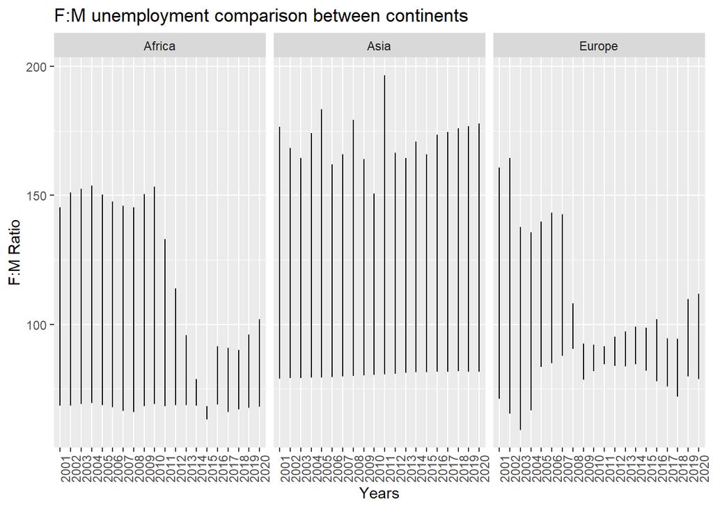

```r
b <- read.csv("C:\\Users\\neelc\\Downloads\\Country Meta-Data.csv")
View(b)

#Creating my own tibble and inner joining with the previously made one
mytable <-  tibble(Country.Name= c("Ethiopia","Guinea", "Iraq", "Liberia", "Lesotho", "China", "India", "Bhutan", "Indonesia", "Sri Lanka", "Albania", "Germany", "Italy", "Spain", "Denamrk"),continent= c("Africa", "Africa", "Africa", "Africa", "Africa", "Asia", "Asia", "Asia","Asia", "Asia", "Europe", "Europe", "Europe", "Europe", "Europe")) %>%
  inner_join(country_tibble, by= "Country.Name") %>%
  inner_join(indicator_data, by= "Country.Code") %>%
  filter(year == (2001:2020))

View(mytable)

#Plotting line grapg
ggplot(data= mytable, aes(x= year, y= value)) +
  geom_line() +
  facet_wrap(.~continent,) +
  theme(axis.text.x = element_text(angle= 90, hjust=0)) +
  ggtitle("F:M unemployment comparison between continents") +
  xlab("Years") + ylab("F:M Ratio")
```